# QTM 151 - Quiz 5

## Try to submit as an HTML file

Print your Emory ID below

```python
# Write your answer here
print(2518804)
```

```
2518804
```

This quiz is open book

- You can use the lecture notes
- You will get partial credit for attempting the questions
- To get full credit, the code should run as intended
- You should NOT communicate with other students

Print the following message:

"I will abide by Emory's code of conduct"

**By printing the message, you acknowledge that you will abide by Emory's code of conduct.**

```python
# Write your answer here:
print("I will abide by Emory's code of conduct")
```

```
I will abide by Emory's code of conduct
```

Import the libraries "matplotlib.pyplot" and "pandas"

```python
# Write your answer here
import pandas as pd
import matplotlib.pyplot as plt
```

In this quiz you will work with data on exchange rates,  
for the following currencies:

- 1 euro (EUR) to dollar (USD)
- 1 pound (GPB) to dollar (USD).

(a) Import and parse dates

- Import the dataset "currencies.csv"
- Parse the "date_string" column with `pd.to_datetime()`
- To get full points, set the "format" option using wildcards as in Lecture 20.

```python
# Write your own code
cur=pd.read_csv('data_raw/currencies.csv')
cur['date']=pd.to_datetime(cur['date_string'],format='%A, %b %d, %Y')
display(cur)
```

|  | date_string | eur_to_usd | gbp_to_usd | date |
| --- | --- | --- | --- | --- |
| 0 | Monday, Jan 04, 1999 | 1.6581 | 1.1812 | 1999-01-04 |
| 1 | Tuesday, Jan 05, 1999 | 1.6566 | 1.1760 | 1999-01-05 |
| 2 | Wednesday, Jan 06, 1999 | 1.6547 | 1.1636 | 1999-01-06 |
| 3 | Thursday, Jan 07, 1999 | 1.6495 | 1.1672 | 1999-01-07 |
| 4 | Friday, Jan 08, 1999 | 1.6405 | 1.1554 | 1999-01-08 |
| ... | ... | ... | ... | ... |
| 6320 | Monday, Mar 27, 2023 | 1.2278 | 1.0789 | 2023-03-27 |
| 6321 | Tuesday, Mar 28, 2023 | 1.2341 | 1.0844 | 2023-03-28 |
| 6322 | Wednesday, Mar 29, 2023 | 1.2313 | 1.0826 | 2023-03-29 |
| 6323 | Thursday, Mar 30, 2023 | 1.2368 | 1.0899 | 2023-03-30 |
| 6324 | Friday, Mar 31, 2023 | 1.2369 | 1.0872 | 2023-03-31 |

6325 rows × 4 columns

(b) Plot multiple time series

- Create a line plot plot which has the "gbp_to_usd" and "eur_to_usd" on the y-axis  
  and the date on the x-axis
- Label the x-axis, the y-axis, and the title
- Add a legend and set the names to "1 Euro to USD" and "1 GPB to USD"

Hint: See Lecture 21 for how to plot multiple columns  
Hint: Remember to include the legend names as a list `[...]`

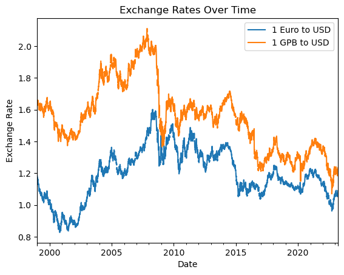

```python
# Write your own code
cur[['date','gbp_to_usd','eur_to_usd']].set_index("date").plot()
plt.xlabel('Date')
plt.ylabel('Exchange Rate')
plt.title('Exchange Rates Over Time')
plt.legend(["1 Euro to USD", "1 GPB to USD"])
```

(c) Compute growth rates

- Calculate a new column "growth_euro" which computes the percentage daily  
  growth rate of "eur_to_usd".

Hint: Use `.diff()` and `.shift(1)` as in Lecture 21

```python
# Write your own code
cur['growth_euro']=(cur['eur_to_usd'].diff() / cur['eur_to_usd'].shift(1)) * 100

display(cur)
```

[output not shown]

(d) Flag subset of data and plot

- Create a boolean colum (True/False) "bool_cond" which checks whether  
  "growth_euro" had a value greater than 2 or less than -2
- Generate a line plot with the "growth_euro" series, label the axes and the title
- Use the command `plt.fill_between()` as in Lecture 21 to create a shaded region  
  for time periods where "bool_cond" is true.

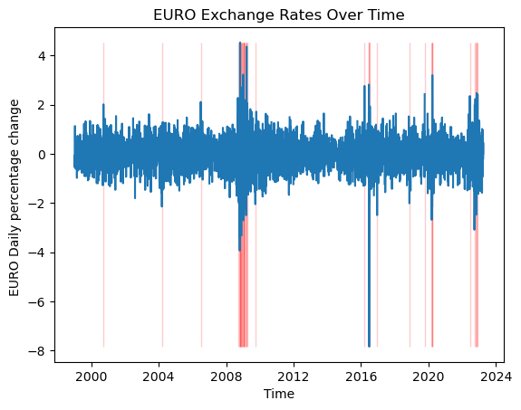

```python
# Write your own code
cur['bool_cond'] = (cur['growth_euro'] > 2) | (cur['growth_euro'] < -2)
vec_y=cur['growth_euro']
plt.plot("date", "growth_euro", data = cur)
plt.xlabel("Time")
plt.ylabel("EURO Daily percentage change ")
plt.title("EURO Exchange Rates Over Time")

plt.fill_between(x= cur["date"],
                 y1=vec_y.min(),
                 y2=vec_y.max(),
                 where=cur['bool_cond'],
                 alpha = 0.2,color = "red")

plt.show()
```

(e) Aggregate dataset by time period

- Create an object "month_config" that uses `pd.Grouper()`, setting the key to  
  the column "date" and freq to "m" (month)
- Follow the instructions in Lecture 20 to compute an aggregate dataset  
  by month which computes the standard deviation of "eur_to_usd"
- Display the dataset

```python
# Write your own code
month_config = pd.Grouper(key='date', freq='M')
monthlydata = (cur
               .groupby(month_config)
               .agg(eur_to_usd_std = ('eur_to_usd','std'))
               .reset_index())
display(monthlydata)
```

|  | date | eur_to_usd_std |
| --- | --- | --- |
| 0 | 1999-01-31 | 0.007345 |
| 1 | 1999-02-28 | 0.013345 |
| 2 | 1999-03-31 | 0.010475 |
| 3 | 1999-04-30 | 0.006172 |
| 4 | 1999-05-31 | 0.013046 |
| ... | ... | ... |
| 286 | 2022-11-30 | 0.027308 |
| 287 | 2022-12-31 | 0.011389 |
| 288 | 2023-01-31 | 0.015046 |
| 289 | 2023-02-28 | 0.008972 |
| 290 | 2023-03-31 | 0.016246 |

291 rows × 2 columns

(f) Convert a dataset to long format

- Convert the currencies dataset to long format using the following inputs

```
var_name   = "type",
value_name = "exchange_rate",
id_vars    = "date",
value_vars = ["eur_to_usd","gbp_to_usd"]
```

- Display the dataset

Hint: See Lecture 21 for details on `pd.melt()`

```python
# Write your own code
long_growth = pd.melt(cur,
                var_name = "type",
                value_name = "exchange_rate",
                id_vars='date',
                value_vars=['eur_to_usd','gbp_to_usd'])

long_growth.sort_values(by='date')
```

|  | date | type | exchange_rate |
| --- | --- | --- | --- |
| 0 | 1999-01-04 | eur_to_usd | 1.6581 |
| 6325 | 1999-01-04 | gbp_to_usd | 1.1812 |
| 1 | 1999-01-05 | eur_to_usd | 1.6566 |
| 6326 | 1999-01-05 | gbp_to_usd | 1.1760 |
| 2 | 1999-01-06 | eur_to_usd | 1.6547 |
| ... | ... | ... | ... |
| 6322 | 2023-03-29 | eur_to_usd | 1.2313 |
| 12648 | 2023-03-30 | gbp_to_usd | 1.0899 |
| 6323 | 2023-03-30 | eur_to_usd | 1.2368 |
| 6324 | 2023-03-31 | eur_to_usd | 1.2369 |
| 12649 | 2023-03-31 | gbp_to_usd | 1.0872 |

12650 rows × 3 columns